# Comprehensive Survival Analysis with ml4time2event

ml4time2event team

2025-11-05

# Overview

The refactored `ml4time2event` package centres on three tidy verbs:

1. create a task with `ml4t2e_task_surv()` or `ml4t2e_task_cr()`
2. fit engines through `ml4t2e_fit()`
3. work with tidy tibbles returned from `predict()`, `ml4t2e_evaluate()`, and `autoplot()`.

This vignette walks through an end-to-end survival workflow that showcases the new API. We will:

- explore the built-in lung cancer dataset
- train a collection of survival engines (with optional ensembling)
- score a hold-out set and compare metrics
- visualise survival curves and permutation-based feature importance
- wrap everything into a reusable pipeline (recipes + resampling)

# 1. Packages and data

```r
library(ml4time2event)
library(dplyr)
library(ggplot2)
```

The NCCTG lung-cancer dataset ships with the package. We convert the event indicator to the 0/1 format expected by the new task constructors.

```r
lung_df <- get_lung_survival_data()

if (is.data.frame(lung_df$status)) {
  lung_df$status <- lung_df$status[[1]]
}

status_max <- max(lung_df$status, na.rm = TRUE)
if (status_max > 1L) {
  # Fall back to 0/1 coding when the source data uses 1/2 indicators
  lung_df$status <- ifelse(lung_df$status == status_max, 1L, 0L)
}

lung_df$status <- as.integer(lung_df$status)

glimpse(lung_df)
```

```
## Rows: 228
## Columns: 11
## $ time             <int> 306, 455, 1010, 210, 883, 1022, 310, 361, 218, 166, 1…
## $ status           <int> 1, 1, 0, 1, 1, 0, 1, 1, 1, 1, 1, 1, 1, 1, 1, 1, 1, 1,…
## $ age              <int> 74, 68, 56, 57, 60, 74, 68, 71, 53, 61, 57, 68, 68, 6…
## $ sex              <fct> Male, Male, Male, Male, Male, Male, Female, Female, M…
## $ ph.ecog          <fct> 1, 0, 0, 1, 0, 1, 2, 2, 1, 2, 1, 2, 1, 2, 1, 1, 1, 2,…
## $ ph.karno         <dbl> 90, 90, 90, 90, 100, 50, 70, 60, 70, 70, 80, 70, 90, …
## $ pat.karno        <dbl> 100, 90, 90, 60, 90, 80, 60, 80, 80, 70, 80, 70, 90, …
## $ meal.cal         <dbl> 1175.0000, 1225.0000, 1227.9846, 1150.0000, 970.0705,…
## $ wt.loss          <dbl> 1.052921, 15.000000, 15.000000, 11.000000, 0.000000, …
## $ age_group        <fct> Elderly, Elderly, Middle, Middle, Middle, Elderly, El…
## $ performance_good <int> 1, 1, 1, 1, 1, 0, 0, 0, 0, 0, 1, 0, 1, 0, 1, 1, 1, 0,…
```

For the remainder of the analysis we keep a simple training / validation split.

```r
#set.seed(123)
train_rows <- sample.int(nrow(lung_df), size = floor(0.7 * nrow(lung_df)))
lung_train <- lung_df[train_rows, ]
lung_test  <- lung_df[-train_rows, ]

sprintf("Training rows: %s  |  Validation rows: %s",
        nrow(lung_train), nrow(lung_test))
```

```
## [1] "Training rows: 159  |  Validation rows: 69"
```

# 2. Build a survival task

Tasks capture the outcome columns, the feature set, and lightweight metadata.

```r
feature_cols <- c("age", "sex", "ph.ecog", "ph.karno", "pat.karno",
                  "meal.cal", "wt.loss")

surv_task <- ml4t2e_task_surv(
  data = lung_train,
  time = "time",
  event = "status",
  features = feature_cols,
  time_units = "days"
)
```

# 3. Fit multiple engines (with optional ensemble)

`ml4t2e_fit()` pulls constructor definitions from the internal registry. The `controls` list lets us share hyperparameters (e.g. the common prediction grid).

```r
surv_fit <- ml4t2e_fit(
  task = surv_task,
  models = c("cox", "random_forest", "gbm"),
  ensemble = "auto",
  controls = list(times = seq(0, 1000, length.out = 75))
)

surv_fit
```

```
## <t2e_fit>
##  outcome: survival
##  models : cox, random_forest, gbm, ensemble
##  time grid points: 75
##  created: 2025-11-05 00:58:15 EST
```

Evaluation on the training data is one function call away.

```r
ml4t2e_evaluate(
  surv_fit,
  metrics = c("c_index", "ibs"),
  include = c("ensemble", "cox", "random_forest", "gbm")
)
```

```
##           model  metric       value
## 1      ensemble c_index   0.3409305
## 2      ensemble     ibs 207.3167083
## 3           cox c_index   0.3505489
## 4           cox     ibs 235.5055235
## 5 random_forest c_index   0.3643492
## 6 random_forest     ibs 200.8733368
## 7           gbm c_index   0.3492420
## 8           gbm     ibs 202.7695112
```

# 4. Score a validation set

The same tidy verbs handle hold-out data. Create a matching task for evaluation, generate predictions, then feed both into `ml4t2e_evaluate()`.

```r
surv_task_val <- ml4t2e_task_surv(
  data = lung_test,
  time = "time",
  event = "status",
  features = feature_cols,
  time_units = "days"
)

surv_preds_val <- predict(
  surv_fit,
  newdata = lung_test,
  times = seq(0, 1000, length.out = 75),
  type = "survival",
  include = c("ensemble", "cox", "random_forest", "gbm")
)

ml4t2e_evaluate(
  surv_preds_val,
  task = surv_task_val,
  metrics = c("c_index", "ibs")
)
```

```
##           model  metric       value
## 1      ensemble c_index   0.4165333
## 2      ensemble     ibs 208.7251705
## 3           cox c_index   0.3802667
## 4           cox     ibs 227.7569533
## 5 random_forest c_index   0.4680000
## 6 random_forest     ibs 220.9020706
## 7           gbm c_index   0.4256000
## 8           gbm     ibs 195.1952994
```

# 5. Visualise survival curves

`autoplot()` works on both fitted objects and tidy prediction tibbles.

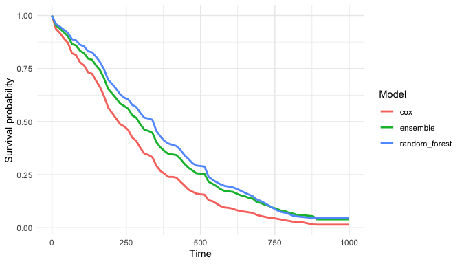

```r
autoplot(surv_fit, include = c("ensemble", "cox", "random_forest"))
```

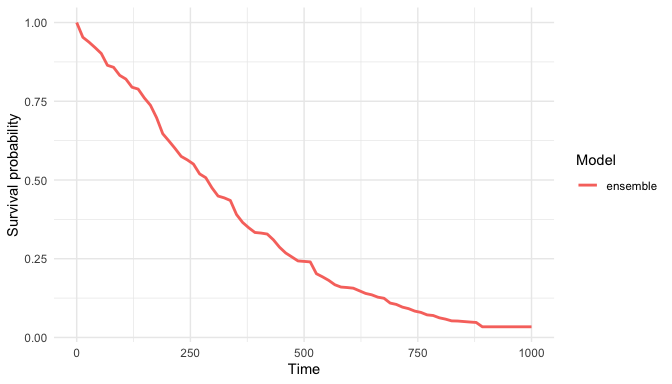

```r
autoplot(surv_preds_val, include = "ensemble")
```

# 6. Permutation-based feature importance

Permutation importance is built into the core API for survival fits.

```r
surv_importance <- ml4t2e_explain(
  surv_fit,
  newdata = lung_test,
  top_n = 6
)

surv_importance
```

```
##            model  metric   feature    importance      method
## 1            cox c_index       sex -0.0757333333 permutation
## 2            cox c_index pat.karno -0.0752000000 permutation
## 3            cox c_index   ph.ecog -0.0640000000 permutation
## 4            cox c_index       age  0.0501333333 permutation
## 5            cox c_index  ph.karno -0.0117333333 permutation
## 6            cox c_index   wt.loss  0.0117333333 permutation
## 7       ensemble c_index       age  0.0704000000 permutation
## 8       ensemble c_index pat.karno -0.0656000000 permutation
## 9       ensemble c_index   wt.loss  0.0208000000 permutation
## 10      ensemble c_index  meal.cal -0.0149333333 permutation
## 11      ensemble c_index       sex -0.0128000000 permutation
## 12      ensemble c_index  ph.karno -0.0064000000 permutation
## 13           gbm c_index       age  0.0768000000 permutation
## 14           gbm c_index pat.karno -0.0762666667 permutation
## 15           gbm c_index  meal.cal -0.0090666667 permutation
## 16           gbm c_index       sex -0.0085333333 permutation
## 17           gbm c_index  ph.karno  0.0085333333 permutation
## 18           gbm c_index   ph.ecog  0.0080000000 permutation
## 19 random_forest c_index  ph.karno -0.0573333333 permutation
## 20 random_forest c_index       age  0.0354666667 permutation
## 21 random_forest c_index pat.karno -0.0312000000 permutation
## 22 random_forest c_index   wt.loss  0.0120000000 permutation
## 23 random_forest c_index  meal.cal -0.0002666667 permutation
## 24 random_forest c_index       sex  0.0000000000 permutation
```

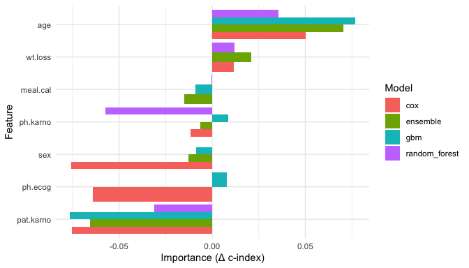

```r
autoplot(surv_importance)
```

# 7. Pipelines with recipes and resampling

For workflows that require preprocessing and resampling, wrap everything in a `T2EPipeline`. Recipes are optional, but when supplied they are baked automatically during prediction/evaluation.

```r
library(recipes)
library(rsample)

surv_pipeline <- ml4t2e_pipeline(
  outcome = list(type = "survival", time = "time", event = "status"),
  models = c("cox", "random_forest"),
  ensemble = "auto",
  recipe = recipe(status ~ ., data = lung_train) |>
    step_impute_median(all_numeric_predictors()) |>
    step_dummy(all_nominal_predictors()),
  resampling = vfold_cv(lung_train, v = 3)
)

surv_pipeline$fit(lung_train)
surv_pipeline$summary()
```

```
## $outcome
## $outcome$type
## [1] "survival"
##
## $outcome$time
## [1] "time"
##
## $outcome$event
## [1] "status"
##
##
## $models
## [1] "cox"           "random_forest"
##
## $ensemble
## [1] "auto"
##
## $features
##  [1] "age"               "ph.karno"          "pat.karno"
##  [4] "meal.cal"          "wt.loss"           "performance_good"
##  [7] "sex_Female"        "ph.ecog_X1"        "ph.ecog_X2"
## [10] "ph.ecog_X3"        "age_group_Middle"  "age_group_Elderly"
##
## $training_metrics
##           model  metric       value
## 1           cox c_index   0.3452169
## 2           cox     ibs 245.4751901
## 3 random_forest c_index   0.3396759
## 4 random_forest     ibs 165.2843239
## 5      ensemble c_index   0.3377940
## 6      ensemble     ibs 194.3137153
##
## $resampling_results
##            model  metric       value split
## 1            cox c_index   0.3467337     1
## 2            cox     ibs 273.0433816     1
## 3  random_forest c_index   0.3547739     1
## 4  random_forest     ibs 203.5544443     1
## 5       ensemble c_index   0.3537688     1
## 6       ensemble     ibs 224.0287005     1
## 7            cox c_index   0.4332400     2
## 8            cox     ibs 291.9615981     2
## 9  random_forest c_index   0.4173669     2
## 10 random_forest     ibs 156.7267143     2
## 11      ensemble c_index   0.4117647     2
## 12      ensemble     ibs 197.9934159     2
## 13           cox c_index   0.3375681     3
## 14           cox     ibs 213.5298025     3
## 15 random_forest c_index   0.3421053     3
## 16 random_forest     ibs 187.3327085     3
## 17      ensemble c_index   0.3402904     3
## 18      ensemble     ibs 197.3844461     3
```

Pipelines expose the same prediction and evaluation helpers:

```r
surv_pipeline$evaluate(
  newdata = lung_test,
  metrics = c("c_index", "ibs"),
  include = "ensemble"
)
```

```
##      model  metric       value
## 1 ensemble c_index   0.4357333
## 2 ensemble     ibs 198.4793674
```

# 8. Persist results

Fits are regular R objects; use `ml4t2e_save()` / `ml4t2e_load()` for the primary API or base R `saveRDS()` for ad-hoc serialization.

```r
tmp_fit <- tempfile(fileext = ".rds")
ml4t2e_save(surv_fit, tmp_fit)
reloaded_fit <- ml4t2e_load(tmp_fit)

tmp_pipe <- tempfile(fileext = ".rds")
saveRDS(surv_pipeline, tmp_pipe)
reloaded_pipeline <- readRDS(tmp_pipe)

reloaded_fit
```

```
## <t2e_fit>
##  outcome: survival
##  models : cox, random_forest, gbm, ensemble
##  time grid points: 75
##  created: 2025-11-05 00:58:15 EST
```

```r
reloaded_pipeline$summary()
```

```
## $outcome
## $outcome$type
## [1] "survival"
##
## $outcome$time
## [1] "time"
##
## $outcome$event
## [1] "status"
##
##
## $models
## [1] "cox"           "random_forest"
##
## $ensemble
## [1] "auto"
##
## $features
##  [1] "age"               "ph.karno"          "pat.karno"
##  [4] "meal.cal"          "wt.loss"           "performance_good"
##  [7] "sex_Female"        "ph.ecog_X1"        "ph.ecog_X2"
## [10] "ph.ecog_X3"        "age_group_Middle"  "age_group_Elderly"
##
## $training_metrics
##           model  metric       value
## 1           cox c_index   0.3452169
## 2           cox     ibs 245.4751901
## 3 random_forest c_index   0.3396759
## 4 random_forest     ibs 165.2843239
## 5      ensemble c_index   0.3377940
## 6      ensemble     ibs 194.3137153
##
## $resampling_results
##            model  metric       value split
## 1            cox c_index   0.3467337     1
## 2            cox     ibs 273.0433816     1
## 3  random_forest c_index   0.3547739     1
## 4  random_forest     ibs 203.5544443     1
## 5       ensemble c_index   0.3537688     1
## 6       ensemble     ibs 224.0287005     1
## 7            cox c_index   0.4332400     2
## 8            cox     ibs 291.9615981     2
## 9  random_forest c_index   0.4173669     2
## 10 random_forest     ibs 156.7267143     2
## 11      ensemble c_index   0.4117647     2
## 12      ensemble     ibs 197.9934159     2
## 13           cox c_index   0.3375681     3
## 14           cox     ibs 213.5298025     3
## 15 random_forest c_index   0.3421053     3
## 16 random_forest     ibs 187.3327085     3
## 17      ensemble c_index   0.3402904     3
## 18      ensemble     ibs 197.3844461     3
```

# Conclusion

The new object-oriented surface keeps common analyses compact:

1. declare a task,
2. fit one or more registry-backed engines (optionally with ensembling),
3. reuse the same tidy outputs across prediction, evaluation, visualisation, and explainability.

The pipeline helpers layer on recipes/resampling without sacrificing the simplicity of the core verbs.